# GSEA_RII

Weihan Liu and Stephanie Konecki

11/11/2019

*install Packages*

```r
#install the needed packages
if (!requireNamespace("BiocManager", quietly = TRUE))
    install.packages("BiocManager")

BiocManager::install("fgsea")
```

*Load required libraries*

```r
#load the needed libraries
library(tidyverse)
```

```r
library(ggplot2)
library(fgsea)
library(DESeq2)
```

*Read in the results table generated by DeSeq2*

```r
library(tidyverse)
RII_DE_result <- read.csv("/Users/stephaniekonecki/Documents/grad\ school/Data/2019/October/SNK015/RII_DE_low\ vs\ ren.csv",stringsAsFactors = FALSE)
colnames(RII_DE_result) <- c("mouse_name","baseMean","log2FoldChange","lfcSE","stat","pvalue","padj")
head(RII_DE_result)
```

```
##   mouse_name   baseMean log2FoldChange     lfcSE       stat    pvalue
## 1   AA388235  55.308817     -0.6114647 0.4960754 -1.2326043 0.2177235
## 2   AA413626   1.759170     -3.0049253 2.7443986 -1.0949304 0.2735472
## 3   AA414768   3.145473     -0.2077198 1.7612292 -0.1179402 0.9061150
## 4   AA415398   4.531843      1.3459518 1.6217617  0.8299319 0.4065773
## 5   AA465934 239.089458     -0.3198036 0.9627357 -0.3321821 0.7397518
## 6   AA467197  81.281022     -0.4775707 0.4222502 -1.1310136 0.2580494
##       padj
## 1       NA
## 2       NA
## 3       NA
## 4       NA
## 5 0.939429
## 6       NA
```

*Rank all genes based on their fold change for RII*

```r
#rank genes based on log2fold change
ranks_RII <- RII_DE_result$log2FoldChange
names(ranks_RII) <- RII_DE_result$gene
head(ranks_RII)
```

```
## [1] -0.6114647 -3.0049253 -0.2077198  1.3459518 -0.3198036 -0.4775707
```

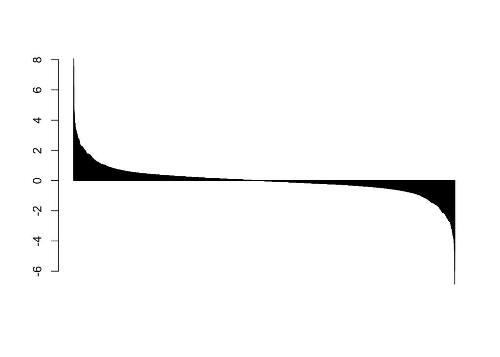

```r
#plot the rank fold change
barplot(sort(ranks_RII,decreasing = T),,axisnames = FALSE)
```

*Parse results table so you only have gene symbol and statistic*

```r
GSEA_RII <- RII_DE_result %>%
  dplyr::select(mouse_name, stat) %>%
  na.omit() %>%
  distinct() %>%
  group_by(mouse_name) %>%
  summarize(stat=mean(stat))
head(GSEA_RII)
```

```
## # A tibble: 6 x 2
##   mouse_name   stat
##   <chr>       <dbl>
## 1 1-Mar      -0.588
## 2 1-Sep      -3.69
## 3 10-Mar     -0.556
## 4 10-Sep     -0.652
## 5 11-Sep      0.410
## 6 15-Sep     -1.76
```

*convert mouse gene names to human gene names*

```r
m_to_h <- read.csv("/Users/stephaniekonecki/Desktop/mouseGeneIDtoHumanSymbol.csv")
colnames(m_to_h) <- c("ID", "mouse_name","human_name")
human_GSEA_RII <- inner_join(GSEA_RII,m_to_h,by = "mouse_name")
human_GSEA_RII <- human_GSEA_RII[,c(2,4)] #keep only the stat and human gene names
human_GSEA_RII<- na.omit(human_GSEA_RII,human_name) #remove all "na" genes
human_GSEA_RII <- human_GSEA_RII[, c("human_name", "stat")] #flips the columns around
colnames(human_GSEA_RII) <- c("gene", "stat")
human_GSEA_RII <- human_GSEA_RII %>% dplyr::arrange(desc(stat))
head(human_GSEA_RII)
```

```
## # A tibble: 6 x 2
##   gene    stat
##   <fct>  <dbl>
## 1 HSPA1A 14.5
## 2 HSPA1B 14.5
## 3 HBZ     8.25
## 4 DCBLD2  7.43
## 5 FGFRL1  7.33
## 6 CBX6    6.78
```

We’re going to use the fgsea package for fast preranked gene set enrichment analysis (GSEA). The fgsea() function requires a list of gene sets to check, and a named vector of gene-level statistics, where the names should be the same as the gene names in the pathways list. First, let’s create our named vector of test statistics. See ?tibble::deframe for help here - deframe() converts two-column data frames to a named vector or list, using the first column as name and the second column as value.

*create dataframe that GSEA likes*

```r
ranks_RII <- deframe(human_GSEA_RII)
head(ranks_RII, 20)
```

```
##    HSPA1A    HSPA1B       HBZ    DCBLD2    FGFRL1      CBX6      ATF5
## 14.489920 14.489920  8.247765  7.430730  7.325827  6.778804  6.765243
##      AGRN    SAPCD2     RRAGD      WNK4      HBE1      ACHE  HSP90AA1
##  6.681306  6.515066  6.499217  6.479366  6.317741  6.000578  5.794266
##     DDHD1     UFSP1     THBS1     FKBP9     MYBL1     CDK17
##  5.754015  5.714879  5.626302  5.464492  5.400000  5.363730
```

Let’s use the Hallmark gene set from MSigDB. Hallmark gene sets summarize and represent specific well-defined biological states or processes and display coherent expression. These gene sets were generated by a computational methodology based on identifying overlaps between gene sets in other MSigDB collections and retaining genes that display coordinate expression. The gmtPathways() function will take a GMT file you downloaded from MSigDB and turn it into a list. Each element in the list is a character vector of genes in the pathway.

*Generate a gene set*

```r
#first, download the pathway from GSEA online to your computer
pathways.hallmark <- gmtPathways("//Users/stephaniekonecki/Desktop/h.all.v7.0.symbols.gmt")  #Load the pathways into a named list

# Show the first few pathways, and within those, show  the first few genes.
pathways.hallmark %>%
  head() %>%
  lapply(head)
```

```
## $HALLMARK_TNFA_SIGNALING_VIA_NFKB
## [1] "JUNB"    "CXCL2"   "ATF3"    "NFKBIA"  "TNFAIP3" "PTGS2"
##
## $HALLMARK_HYPOXIA
## [1] "PGK1"  "PDK1"  "GBE1"  "PFKL"  "ALDOA" "ENO2"
##
## $HALLMARK_CHOLESTEROL_HOMEOSTASIS
## [1] "FDPS"    "CYP51A1" "IDI1"    "FDFT1"   "DHCR7"   "SQLE"
##
## $HALLMARK_MITOTIC_SPINDLE
## [1] "ARHGEF2"    "CLASP1"     "KIF11"      "AC027237.1" "ALS2"
## [6] "ARF6"
##
## $HALLMARK_WNT_BETA_CATENIN_SIGNALING
## [1] "MYC"    "CTNNB1" "JAG2"   "NOTCH1" "DLL1"   "AXIN2"
##
## $HALLMARK_TGF_BETA_SIGNALING
## [1] "TGFBR1" "SMAD7"  "TGFB1"  "SMURF2" "SMURF1" "BMPR2"
```

*compare your data to the geneset*

```r
library(DT)

GSEA_results_RII <- fgsea(pathways=pathways.hallmark, stats=ranks_RII, nperm=1000)
#this compares the hallmark pathway, via the stats in our RII experiment, 1000 times

#Tidy the results:
tidy_GSEA_results_RII <- GSEA_results_RII %>%
  as_tibble() %>%
  dplyr::arrange(desc(NES))

# Show in a nice table:
tidy_GSEA_results_RII %>%
  dplyr::select(-leadingEdge, -ES, -nMoreExtreme) %>%
  dplyr::arrange(padj) %>%
  DT::datatable()
```

|  | pathway | pval | padj | NES | size |
| --- | --- | --- | --- | --- | --- |
| 1 | HALLMARK_G2M_CHECKPOINT | 0.00156739811912226 | 0.0114468864468864 | 2.74724461178619 | 180 |
| 2 | HALLMARK_E2F_TARGETS | 0.0015527950310559 | 0.0114468864468864 | 2.73111952955499 | 194 |
| 3 | HALLMARK_MITOTIC_SPINDLE | 0.0015600624024961 | 0.0114468864468864 | 2.15254383041212 | 189 |
| 4 | HALLMARK_MYC_TARGETS_V1 | 0.0015625 | 0.0114468864468864 | 1.95466307236389 | 190 |
| 5 | HALLMARK_UNFOLDED_PROTEIN_RESPONSE | 0.00165289256198347 | 0.0114468864468864 | 1.84129687518257 | 108 |
| 6 | HALLMARK_MTORC1_SIGNALING | 0.00154083204930663 | 0.0114468864468864 | 1.69124989790208 | 197 |
| 7 | HALLMARK_OXIDATIVE_PHOSPHORYLATION | 0.00268096514745308 | 0.0114468864468864 | -1.48935254219099 | 176 |
| 8 | HALLMARK_COMPLEMENT | 0.00269541778975741 | 0.0114468864468864 | -1.51420169234186 | 165 |
| 9 | HALLMARK_KRAS_SIGNALING_UP | 0.00272479564032698 | 0.0114468864468864 | -1.54852704958486 | 169 |
| 10 | HALLMARK_COAGULATION | 0.00248756218905473 | 0.0114468864468864 | -1.68737394784389 | 107 |

[output cut: 40 more lines]

```r
# if you run this in terminal you can save this table as a website to go back to in the future
```

*generate the enrichment score plot for one pathway*

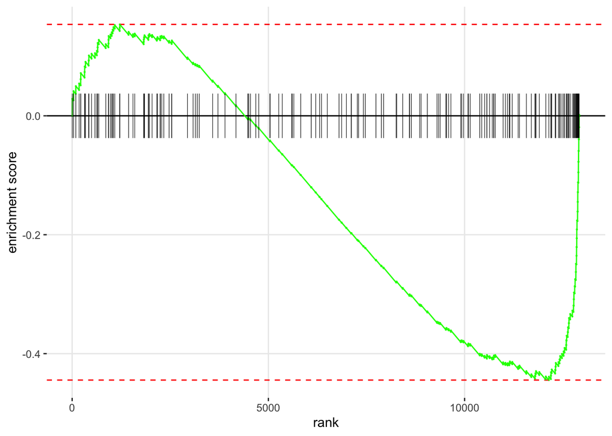

```r
#plot the enrichment score for a pathway of interest
plotEnrichment(pathways.hallmark[["HALLMARK_HEME_METABOLISM"]], ranks_RII)
```

*Plot the normalized enrichment score for all the pathways*

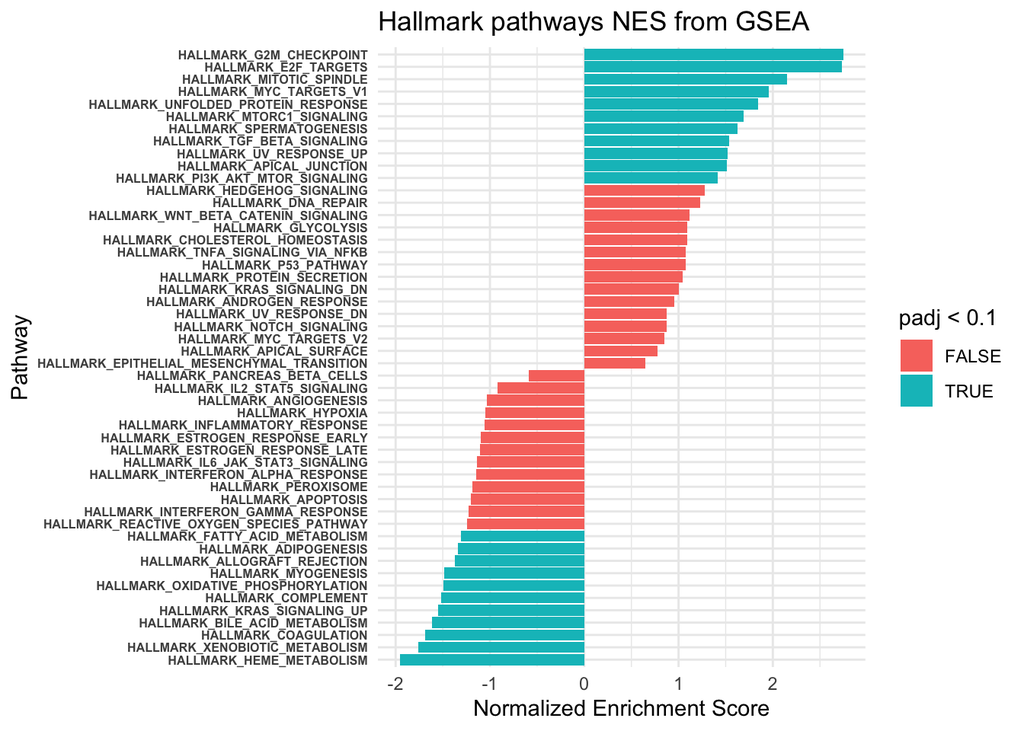

```r
#the bars are colored based on signifance
ggplot(tidy_GSEA_results_RII, aes(reorder(pathway, NES), NES)) +
  geom_col(aes(fill=padj<0.1)) +
  coord_flip() +
  labs(x="Pathway", y="Normalized Enrichment Score",
       title="Hallmark pathways NES from GSEA") +
  theme_minimal() +
        theme(axis.text.y=element_text(size=6, face = "bold"))
```